# Emisiones de CO2 en el mundo.

## Datos CO2

El siguiente enlace [WorldBankCO2](https://mkt.tableau.com/Public/Datasets/World_Bank_CO2.xlsx) nos da acceso a un conocido data set de [THE WORLD BANK](https://datacatalog.worldbank.org/). En concreto la versión de este data set es la de de [Tableau Open Data Sets](https://www.tableau.com/learn/articles/free-public-data-sets) una colección de datos del programa [Tableau](https://public.tableau.com/en-us/s/gallery) que es un programa para representar gráficas, paneles de control o *dahsboards* y los llamados KPIs.

En esta actividad se trata en primer lugar que entendáis los datos del fichero y que lo leáis de forma directa desde el archivo .xlsx y transforméis en tibbles o data frames de R.

Por ejemplo el siguiente código nos da los nombres de las sheets del fichero

```r
library(readxl)
filename="World_Bank_CO2.xlsx"
sheets_names <- readxl::excel_sheets(filename)
sheets_names
```

```
## [1] "About"                    "CO2 (kt) Pivoted"
## [3] "CO2 (kt) RAW DATA"        "CO2 Data Cleaned"
## [5] "CO2 (kt) for Split"       "CO2 for World to Union"
## [7] "CO2 Per Capita RAW DATA"  "CO2 Per Capita (Pivoted)"
## [9] "Metadata - Countries"
```

Ahora podemos leer cada hoja

```r
read_excel_allsheets <- function(filename) {
    sheets_names <- readxl::excel_sheets(filename)
    x <- lapply(sheets_names, function(X) readxl::read_excel(filename, sheet = X))
    names(x) <- sheets_names
    return(x)
    }
```

El siguiente código lee todas las sheets del excel y pone cada una en una lista de objetos llamada all_data_CO2. Cada objeto se llama con el nombre de la hoja

```r
all_data_CO2=read_excel_allsheets(filename)
class(all_data_CO2)
```

```
## [1] "list"
```

```r
lapply(all_data_CO2,FUN=function(x) c(class=paste(class(x),collapse=", "),col_names=paste(names(x),collapse=", ")))
```

```
## $About
##                                                                                                                                              class
##                                                                                                                          "tbl_df, tbl, data.frame"
##                                                                                                                                          col_names
## "Data from http://data.worldbank.org/indicator/EN.ATM.CO2E.PC and http://data.worldbank.org/indicator/EN.ATM.CO2E.KT both last updated 02/05/2016"
##
## $`CO2 (kt) Pivoted`
##                                                class
##                            "tbl_df, tbl, data.frame"
##                                            col_names
## "Country Name, Country Code, Region, Year, CO2 (kt)"
##
## $`CO2 (kt) RAW DATA`
##                                                                                                                                                                                                                                                                                                          …
##                                                                                                                                                                                                                                                                                                          …
##                                                                                                                                                                                                                                                                                                          …
## "Country Name, Country Code, Indicator Name, Indicator Code, 1960, 1961, 1962, 1963, 1964, 1965, 1966, 1967, 1968, 1969, 1970, 1971, 1972, 1973, 1974, 1975, 1976, 1977, 1978, 1979, 1980, 1981, 1982, 1983, 1984, 1985, 1986, 1987, 1988, 1989, 1990, 1991, 1992, 1993, 1994, 1995, 1996, 1997, 1998, 19…
##
## $`CO2 Data Cleaned`
##                                                                              class
##                                                          "tbl_df, tbl, data.frame"
##                                                                          col_names
## "Country Code, Country Name, Region, Year, CO2 (kt), CO2 Per Capita (metric tons)"
##
## $`CO2 (kt) for Split`
##                                                class
##                            "tbl_df, tbl, data.frame"
##                                            col_names
## "Country Code, Country Name, Region, Year, CO2 (kt)"
##
## $`CO2 for World to Union`
##                     class                 col_names
## "tbl_df, tbl, data.frame"                        ""
##
## $`CO2 Per Capita RAW DATA`
##                                                                                                                                                                                                                                                                                                          …
##                                                                                                                                                                                                                                                                                                          …
##                                                                                                                                                                                                                                                                                                          …
## "Country Name, Country Code, Indicator Name, Indicator Code, 1960, 1961, 1962, 1963, 1964, 1965, 1966, 1967, 1968, 1969, 1970, 1971, 1972, 1973, 1974, 1975, 1976, 1977, 1978, 1979, 1980, 1981, 1982, 1983, 1984, 1985, 1986, 1987, 1988, 1989, 1990, 1991, 1992, 1993, 1994, 1995, 1996, 1997, 1998, 19…
##
## $`CO2 Per Capita (Pivoted)`
##                                                            class
##                                        "tbl_df, tbl, data.frame"
##                                                        col_names
## "Country Name, Country Code, Year, CO2 Per Capita (metric tons)"
##
## $`Metadata - Countries`
##                                                        class
##                                    "tbl_df, tbl, data.frame"
##                                                    col_names
## "Country Code, Region, IncomeGroup, SpecialNotes, TableName"
```

## Contexto mundial en emisiones de contaminantes

Os pongo algunos enlaces. A partir de estos buscad más.

- [Protocolo de kioto (wikipedia)](https://es.wikipedia.org/wiki/Protocolo_de_Kioto)
- [Cambio Climático .org](http://www.cambioclimatico.org/tema/protocolo-de-kyoto)
- [Acuerdo de París](https://es.wikipedia.org/wiki/Acuerdo_de_Par%C3%ADs)
- [Acuerdo de París Comisón Europea](https://ec.europa.eu/clima/policies/international/negotiations/paris_es)

## Un gráfico

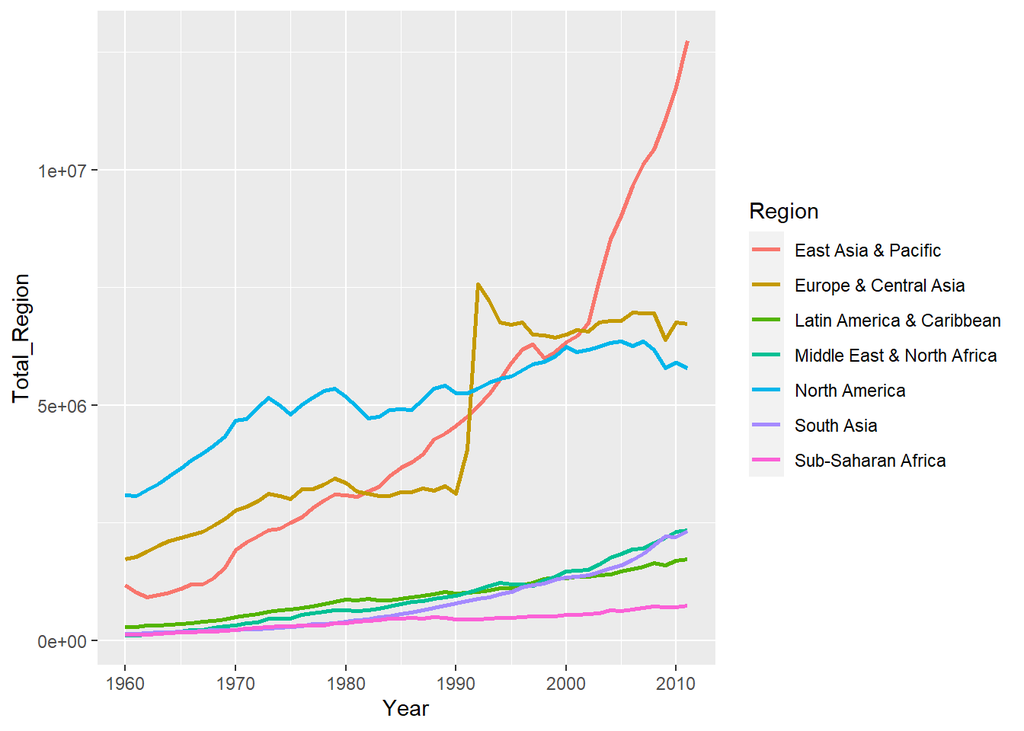

```r
all_data_CO2$`CO2 (kt) Pivoted`%>% group_by(`Year`,`Region`) %>% summarise(Total_Region=sum(`CO2 (kt)`,na.rm=TRUE)) %>% ggplot(aes(x = Year, y = `Total_Region`)) +   geom_line(aes(color = `Region`), size = 1)
```

## Conversiones desde los raw data y ajuste de metadatos

Primero por unas cuestiones de comodidad modificarermos los nombres de las tibbles y de las variables de cada tibble para no necesitar ponerlos entre ``.

```r
data_CO2=all_data_CO2
names(data_CO2)
```

```
## [1] "About"                    "CO2 (kt) Pivoted"
## [3] "CO2 (kt) RAW DATA"        "CO2 Data Cleaned"
## [5] "CO2 (kt) for Split"       "CO2 for World to Union"
## [7] "CO2 Per Capita RAW DATA"  "CO2 Per Capita (Pivoted)"
## [9] "Metadata - Countries"
```

```r
long_names=names(data_CO2)# los guardo para el jefe
long_names
```

```
## [1] "About"                    "CO2 (kt) Pivoted"
## [3] "CO2 (kt) RAW DATA"        "CO2 Data Cleaned"
## [5] "CO2 (kt) for Split"       "CO2 for World to Union"
## [7] "CO2 Per Capita RAW DATA"  "CO2 Per Capita (Pivoted)"
## [9] "Metadata - Countries"
```

```r
arreglo_names=function(x) return(gsub("_$","",gsub("(__+)","_",gsub("\\(|\\)|\\-|\\s","_",names(x)))))
names(data_CO2)=arreglo_names(data_CO2)
names(data_CO2)
```

```
## [1] "About"                   "CO2_kt_Pivoted"
## [3] "CO2_kt_RAW_DATA"         "CO2_Data_Cleaned"
## [5] "CO2_kt_for_Split"        "CO2_for_World_to_Union"
## [7] "CO2_Per_Capita_RAW_DATA" "CO2_Per_Capita_Pivoted"
## [9] "Metadata_Countries"
```

```r
for(sheet in 1:length(data_CO2)) {
names(data_CO2[[sheet]])=arreglo_names(data_CO2[[sheet]])
}


print(data_CO2$CO2_kt_RAW_DATA,n=20,width = Inf)
```

```
## # A tibble: 248 x 60
##    Country_Name         Country_Code Indicator_Name     Indicator_Code
##    <chr>                <chr>        <chr>              <chr>
##  1 Aruba                ABW          CO2 emissions (kt) EN.ATM.CO2E.KT
##  2 Andorra              AND          CO2 emissions (kt) EN.ATM.CO2E.KT
##  3 Afghanistan          AFG          CO2 emissions (kt) EN.ATM.CO2E.KT
##  4 Angola               AGO          CO2 emissions (kt) EN.ATM.CO2E.KT
##  5 Romania              ALB          CO2 emissions (kt) EN.ATM.CO2E.KT
##  6 Arab World           ARB          CO2 emissions (kt) EN.ATM.CO2E.KT
##  7 United Arab Emirates ARE          CO2 emissions (kt) EN.ATM.CO2E.KT
##  8 Argentina            ARG          CO2 emissions (kt) EN.ATM.CO2E.KT
##  9 Armenia              ARM          CO2 emissions (kt) EN.ATM.CO2E.KT
## 10 American Samoa       ASM          CO2 emissions (kt) EN.ATM.CO2E.KT
## 11 Antigua and Barbuda  ATG          CO2 emissions (kt) EN.ATM.CO2E.KT
## 12 Australia            AUS          CO2 emissions (kt) EN.ATM.CO2E.KT
```

[output cut: 295 more lines]

```r
glimpse(data_CO2$CO2_kt_RAW_DATA) # es similar en algunos caso a str pero es mas adecuado para tibbñles complejas
```

```
## Rows: 248
## Columns: 60
## $ Country_Name   <chr> "Aruba", "Andorra", "Afghanistan", "Angola", "Romani...
## $ Country_Code   <chr> "ABW", "AND", "AFG", "AGO", "ALB", "ARB", "ARE", "AR...
## $ Indicator_Name <chr> "CO2 emissions (kt)", "CO2 emissions (kt)", "CO2 emi...
## $ Indicator_Code <chr> "EN.ATM.CO2E.KT", "EN.ATM.CO2E.KT", "EN.ATM.CO2E.KT"...
## $ `1960`         <chr> "null", "null", "414.371", "550.05", "2024.184", "59...
## $ `1961`         <chr> "null", "null", "491.378", "454.708", "2280.874", "6...
## $ `1962`         <chr> "null", "null", "689.396", "1180.774", "2464.224", "...
## $ `1963`         <chr> "null", "null", "707.731", "1151.438", "2082.856", "...
## $ `1964`         <chr> "null", "null", "839.743", "1224.778", "2016.85", "1...
## $ `1965`         <chr> "null", "null", "1008.425", "1188.108", "2174.531", ...
## $ `1966`         <chr> "null", "null", "1092.766", "1554.808", "2552.232", ...
## $ `1967`         <chr> "null", "null", "1283.45", "993.757", "2680.577", "1...
## $ `1968`         <chr> "null", "null", "1224.778", "1672.152", "3072.946", ...
```

[output cut: 47 more lines]

```r
#str(all_data_CO2$`CO2_(kt)_RAW_DATA`)

library(naniar)# cargar para la función replace_with_na. El paquete naniar aporta utilizades para eliminar NA
# ver un manual en https://cran.r-project.org/web/packages/naniar/vignettes/getting-started-w-naniar.html
data_CO2$CO2_kt_RAW_DATA %>% gather(`1960`:`2015`, key="Year", value="CO2") %>%
  naniar::replace_with_na(replace =list(CO2 ="null")) %>%
  mutate(Year=as.integer(Year),CO2=as.numeric(CO2)) %>%
  arrange(Country_Code) -> aux


print(aux,n=10,width=Inf)
```

```
## # A tibble: 13,888 x 6
##    Country_Name Country_Code Indicator_Name     Indicator_Code  Year   CO2
##    <chr>        <chr>        <chr>              <chr>          <int> <dbl>
##  1 Aruba        ABW          CO2 emissions (kt) EN.ATM.CO2E.KT  1960    NA
##  2 Aruba        ABW          CO2 emissions (kt) EN.ATM.CO2E.KT  1961    NA
##  3 Aruba        ABW          CO2 emissions (kt) EN.ATM.CO2E.KT  1962    NA
##  4 Aruba        ABW          CO2 emissions (kt) EN.ATM.CO2E.KT  1963    NA
##  5 Aruba        ABW          CO2 emissions (kt) EN.ATM.CO2E.KT  1964    NA
##  6 Aruba        ABW          CO2 emissions (kt) EN.ATM.CO2E.KT  1965    NA
##  7 Aruba        ABW          CO2 emissions (kt) EN.ATM.CO2E.KT  1966    NA
##  8 Aruba        ABW          CO2 emissions (kt) EN.ATM.CO2E.KT  1967    NA
##  9 Aruba        ABW          CO2 emissions (kt) EN.ATM.CO2E.KT  1968    NA
## 10 Aruba        ABW          CO2 emissions (kt) EN.ATM.CO2E.KT  1969    NA
## # ... with 13,878 more rows
```

```r
periodos=table(data_CO2$CO2_kt_Pivoted$Year)
periodos
```

```
##
## 1960 1961 1962 1963 1964 1965 1966 1967 1968 1969 1970 1971 1972 1973 1974 1975
##  213  214  214  214  214  214  214  214  214  214  214  214  214  214  214  214
## 1976 1977 1978 1979 1980 1981 1982 1983 1984 1985 1986 1987 1988 1989 1990 1991
##  214  214  214  214  214  214  214  214  214  214  214  214  214  214  214  214
## 1992 1993 1994 1995 1996 1997 1998 1999 2000 2001 2002 2003 2004 2005 2006 2007
##  214  214  214  214  214  214  214  214  214  214  214  214  214  214  214  214
## 2008 2009 2010 2011
##  214  214  214  214
```

```r
all(periodos==214)# hay alguno el primero 1960 que parece que falta algo
```

```
## [1] FALSE
```

```r
year_country=table(data_CO2$CO2_kt_Pivoted$Year,data_CO2$CO2_kt_Pivoted$Country_Code)
#year_country # es muy grande mejor contemos las frecuencias de apariciones
table(year_country)
```

```
## year_country
##     0     1
##     1 11127
```

```r
str(year_country)
```

```
##  'table' int [1:52, 1:214] 1 1 1 1 1 1 1 1 1 1 ...
##  - attr(*, "dimnames")=List of 2
##   ..$ : chr [1:52] "1960" "1961" "1962" "1963" ...
##   ..$ : chr [1:214] "ABW" "AFG" "AGO" "ALB" ...
```

```r
indice=which(year_country==0,arr.ind = TRUE)
indice
```

```
##      row col
## 1960   1 174
```

```r
dimnames(year_country)[[1]][indice[1]]
```

```
## [1] "1960"
```

```r
dimnames(year_country)[[2]][indice[2]]
```

```
## [1] "SMR"
```

```r
data_CO2$CO2_kt_Pivoted[data_CO2$CO2_kt_Pivoted$Country_Code=="SMR",]
```

```
## # A tibble: 51 x 5
##    Country_Name Country_Code Region                 Year CO2_kt
##    <chr>        <chr>        <chr>                 <dbl>  <dbl>
##  1 San Marino   SMR          Europe & Central Asia  1961     NA
##  2 San Marino   SMR          Europe & Central Asia  1962     NA
##  3 San Marino   SMR          Europe & Central Asia  1963     NA
##  4 San Marino   SMR          Europe & Central Asia  1964     NA
##  5 San Marino   SMR          Europe & Central Asia  1965     NA
##  6 San Marino   SMR          Europe & Central Asia  1966     NA
##  7 San Marino   SMR          Europe & Central Asia  1967     NA
##  8 San Marino   SMR          Europe & Central Asia  1968     NA
##  9 San Marino   SMR          Europe & Central Asia  1969     NA
## 10 San Marino   SMR          Europe & Central Asia  1970     NA
## # ... with 41 more rows
```

```r
inner_join(aux,data_CO2$CO2_kt_Pivoted) %>% mutate(dif=CO2-CO2_kt) -> aux2
summary(aux2$dif)# los errores pueden ser debidos al redondeo al convertir as.numeric(CO2)
```

```
##    Min. 1st Qu.  Median    Mean 3rd Qu.    Max.    NA's
##  -5e-03  -2e-03   0e+00  -3e-04   1e-03   4e-03    2095
```

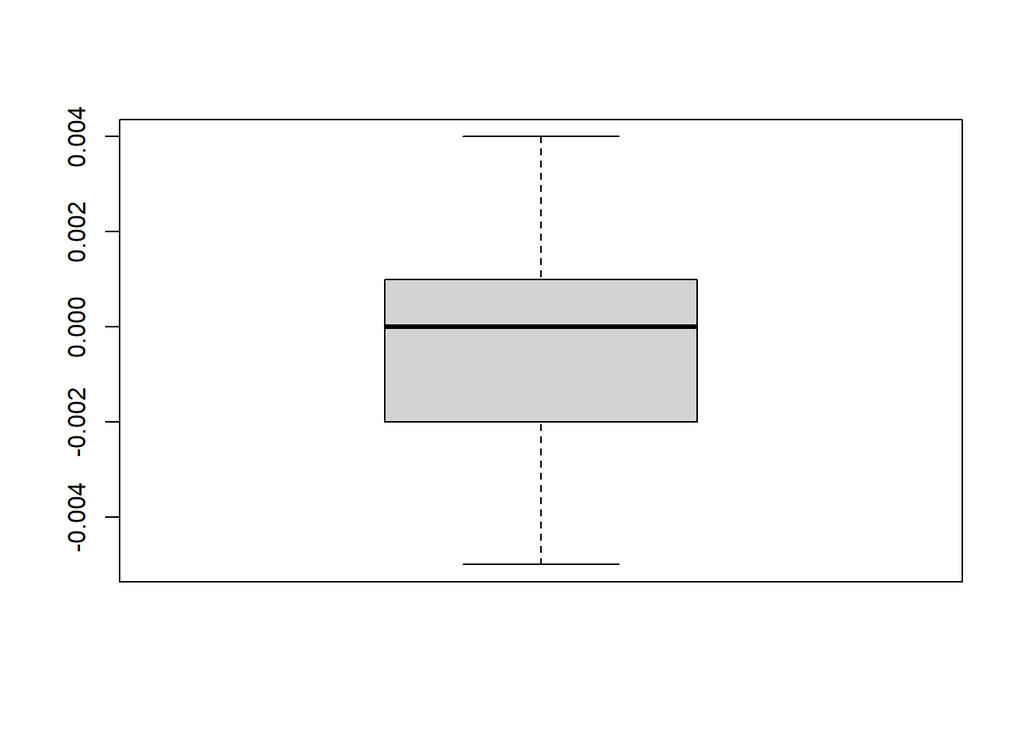

```r
boxplot(aux2$dif)
```

```r
print(aux2,whihd=Inf)
```

```
## # A tibble: 11,075 x 9
##    Country_Name Country_Code Indicator_Name Indicator_Code  Year   CO2 Region
##    <chr>        <chr>        <chr>          <chr>          <dbl> <dbl> <chr>
##  1 Aruba        ABW          CO2 emissions~ EN.ATM.CO2E.KT  1960    NA Latin~
##  2 Aruba        ABW          CO2 emissions~ EN.ATM.CO2E.KT  1961    NA Latin~
##  3 Aruba        ABW          CO2 emissions~ EN.ATM.CO2E.KT  1962    NA Latin~
##  4 Aruba        ABW          CO2 emissions~ EN.ATM.CO2E.KT  1963    NA Latin~
##  5 Aruba        ABW          CO2 emissions~ EN.ATM.CO2E.KT  1964    NA Latin~
##  6 Aruba        ABW          CO2 emissions~ EN.ATM.CO2E.KT  1965    NA Latin~
##  7 Aruba        ABW          CO2 emissions~ EN.ATM.CO2E.KT  1966    NA Latin~
##  8 Aruba        ABW          CO2 emissions~ EN.ATM.CO2E.KT  1967    NA Latin~
##  9 Aruba        ABW          CO2 emissions~ EN.ATM.CO2E.KT  1968    NA Latin~
## 10 Aruba        ABW          CO2 emissions~ EN.ATM.CO2E.KT  1969    NA Latin~
## # ... with 11,065 more rows, and 2 more variables: CO2_kt <dbl>, dif <dbl>
```

```r
data_clean=aux2 %>% inner_join(data_CO2$CO2_Per_Capita_Pivoted) %>% inner_join(data_CO2$Metadata_Countries)
```

### Preguntas y gráficos

```r
glimpse(data_clean)
```

```
## Rows: 11,075
## Columns: 13
## $ Country_Name               <chr> "Aruba", "Aruba", "Aruba", "Aruba", "Aru...
## $ Country_Code               <chr> "ABW", "ABW", "ABW", "ABW", "ABW", "ABW"...
## $ Indicator_Name             <chr> "CO2 emissions (kt)", "CO2 emissions (kt...
## $ Indicator_Code             <chr> "EN.ATM.CO2E.KT", "EN.ATM.CO2E.KT", "EN....
## $ Year                       <dbl> 1960, 1961, 1962, 1963, 1964, 1965, 1966...
## $ CO2                        <dbl> NA, NA, NA, NA, NA, NA, NA, NA, NA, NA, ...
## $ Region                     <chr> "Latin America & Caribbean", "Latin Amer...
## $ CO2_kt                     <dbl> NA, NA, NA, NA, NA, NA, NA, NA, NA, NA, ...
## $ dif                        <dbl> NA, NA, NA, NA, NA, NA, NA, NA, NA, NA, ...
## $ CO2_Per_Capita_metric_tons <dbl> NA, NA, NA, NA, NA, NA, NA, NA, NA, NA, ...
## $ IncomeGroup                <chr> "High income: nonOECD", "High income: no...
## $ SpecialNotes               <chr> "SNA data for 2000-2011 are updated from...
## $ TableName                  <chr> "Aruba", "Aruba", "Aruba", "Aruba", "Aru...
```

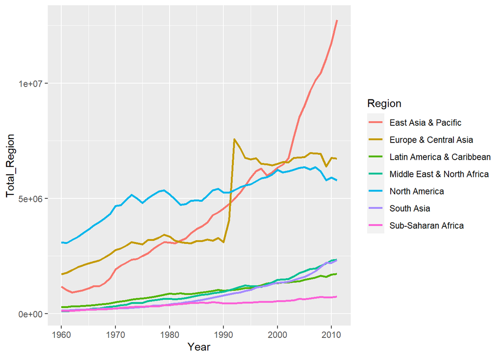

```r
data_clean %>% group_by(Year,Region) %>% summarise(Total_Region=sum(CO2_kt,na.rm=TRUE)) %>% ggplot(aes(x = Year, y = Total_Region)) +   geom_line(aes(color = Region), size = 1)
```

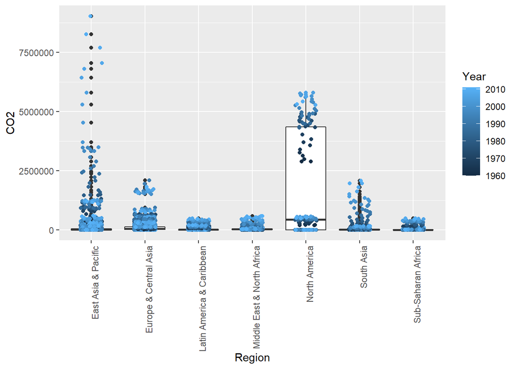

```r
data_clean %>% ggplot(aes(Region,CO2,colour=Year)) + geom_boxplot() + theme(axis.text.x = element_text(angle = 90, hjust = 1)) + geom_jitter(width = 0.2)
```

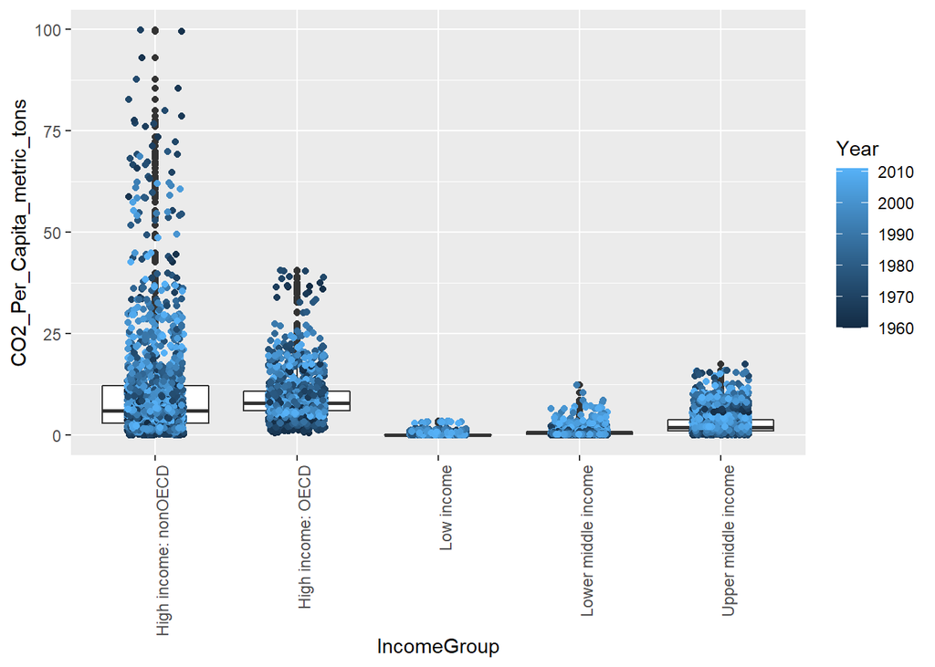

```r
data_clean %>% ggplot(aes(IncomeGroup,CO2_Per_Capita_metric_tons,colour=Year)) + geom_boxplot() + theme(axis.text.x = element_text(angle = 90, hjust = 1)) + geom_jitter(width = 0.2)
```

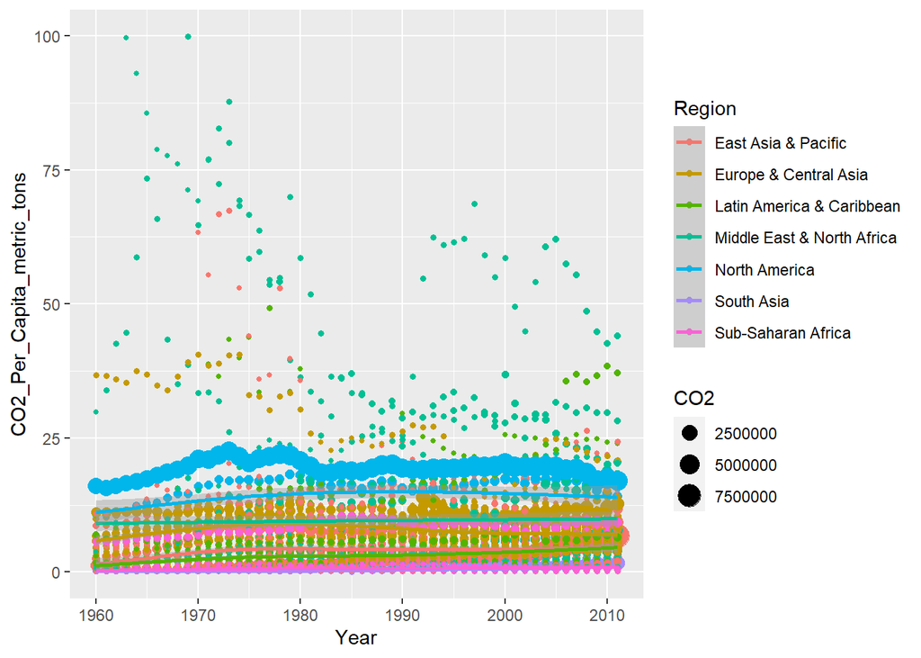

```r
data_clean %>% ggplot(aes(Year,CO2_Per_Capita_metric_tons,colour=Region)) + geom_point(aes(size=CO2) ) + geom_smooth()
```

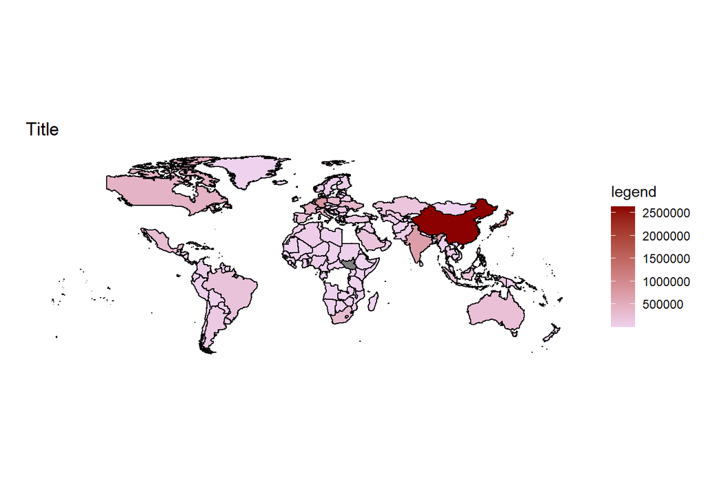

```r
WorldData <- map_data('world')
#df <-data.frame(region=c('Hungary','Lithuania','Argentina'),value=c(4,10,11))
color= data_clean %>% group_by(Country_Name) %>% summarise(media=mean(CO2,na.rm=TRUE))
Mydata_plot <- inner_join(WorldData , color,by=c("region"="Country_Name"))
Mydata_plot %>% ggplot() +
  geom_polygon(data=Mydata_plot, aes(x=long, y=lat, group = group,fill=media),colour="black") +
  scale_fill_continuous(low = "thistle2", high = "darkred", guide="colorbar") +
  theme_bw() +
  labs(fill = "legend" ,title = "Title", x="", y="") +
  scale_y_continuous(breaks=c()) +
  scale_x_continuous(breaks=c()) +
  theme(panel.border =  element_blank())+coord_fixed(1)
```